# Introduction to NLP

# What is NLP?

[figure not shown]

# What is NLP?

Broadly, its a field of analytics that's focused on machine understanding of human language (and often how we can efficiently analyze and process large corpora of natural language data into space-efficient numerical representations)

## Major applications include:

- Machine translation
- Speech recognition
- Question answering
- Text summarization
- Chatbots
- Sentiment analysis

## Multiple approaches:

- Rules based
- Classical statistics
- Neural networks

# Tokenization

Tokenization is the process of splitting text into its atoms: words, punctuation, symbols, numbers, etc.

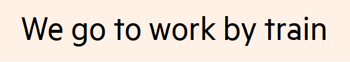

becomes

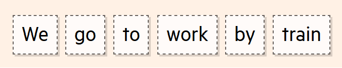

# Part-of-Speech Tagging

Part-of-speech (POS) tagging is the process of assigning, as the name suggests, parts of speech to each word token: noun, verb, adverb, adjective, etc.

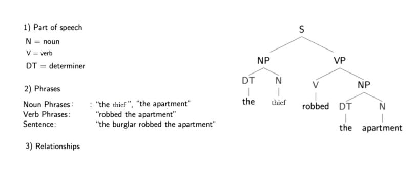

## Dependency Parsing

Dependency parsing involves labeling the relationships between individual tokens within a span: for example, in our above example, we might specify that "the apartment" is the object of the verb "robbed".

## Chunking

Chunking identifies multiple, related tokens into a single token. For example, "New York City" could be treated as a single token despite being three separate words.

## Named Entity Recognition

Named entity recognition is the process of assigning labels to known entities: names, locations, dates, currencies, and so forth.

# Lemmatization

Language is weird! It's fun. Except for NLP. Because we need to understand that "am", "will be", "was", and "have been" are all actually just different conjucations of the same verb.

Lemmatization refers to this process: instead of having to work with all word variants, we can just work directly with the word's base to simplify things a bit.

# Stemming

Stemming is a similar proces to lemmatization, but a little bit simpler. Here, we're just reducing words to their stems (so creative in what we name these things). For example, "big", "bigger", and "biggest" would all be stemmed to "big-".

We use stemming as a bit of a shortcut since it's substantially cheaper than lemmatization: we don't need to understand the part of speech, or any other metadata about the word or chunk. We can just take a hammer to things and break off all the bits at the end of the word that we don't like.

# So what?

[figure not shown]

# Bag of Words

Orderless document representation: frequencies of words from a dictionary Salton & McGill (1983)

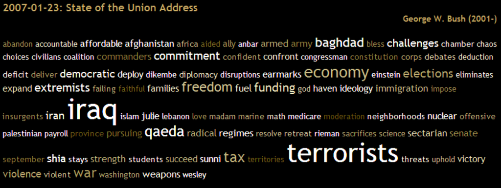

```python
from tensorflow import keras
from typing import List
from keras.preprocessing.text import Tokenizer

sentence = ["John likes to watch movies. Mary likes movies too."]

tokenizer = Tokenizer()
tokenizer.fit_on_texts(sentence)
sequences = tokenizer.texts_to_sequences(sentence)
word_index = tokenizer.word_index
bow = {}
for key in word_index:
    bow[key] = sequences[0].count(word_index[key])

print(f"Bag of word sentence 1:\n{bow}")
print(f"We found {len(word_index)} unique tokens.")
```

```
Bag of word sentence 1:
{'likes': 2, 'movies': 2, 'john': 1, 'to': 1, 'watch': 1, 'mary': 1, 'too': 1}
We found 7 unique tokens.
```

# Term-Document Matrices

- Each cell is the count of term $t$ in document $d(tf_{t,d})$
- Each document is a count vector in $\mathbb{N}^V$
- Two documents are similar if their vectors are similar

[figure not shown]

## Visualizing Document Vectors

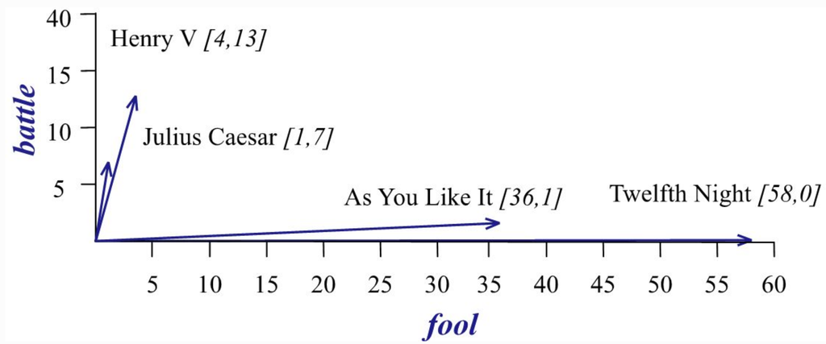

*Slide from Jurafsky & Martin*

### Vectors as Basis for Information Retrieval

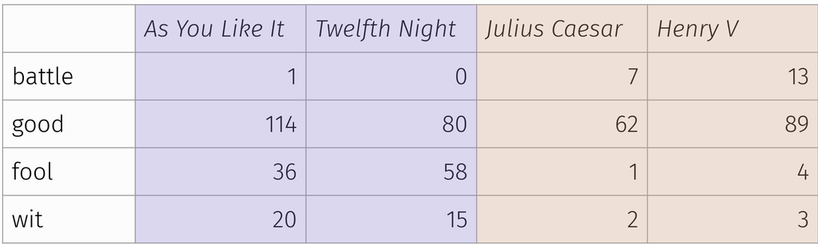

- Vectors for comedies are different from tragedies
- Comedies have more fools and fewer battles

*Slide adapted from Jurafsky & Martin*

# Word-Context Matrices

- Instead of entire documents, we can use smaller contexts (e.g., paragraphs or windows of a few words):

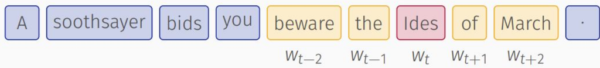

- A word is now defined by a vector over counts of words in context
  - If a word $w_j$ occurs in the context of $w_i$, increase $count_{ij}$
- Assuming we have $V$ words, each vector is now of length $V$
  - The word-word matrix is shape $V\times V$

*Slide credit: David Mortensen*

### Sample contexts of $\pm7$ words

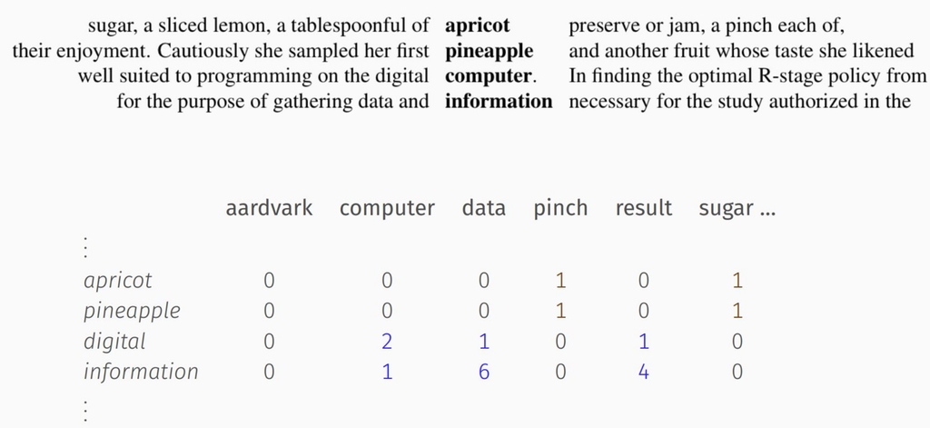

In actual applications, the word-word matrix will be significantly larger --- 10s of thousands of words on both axes

- This results in sparse matrices: most values are 0 because most words will never appear in another word's context window

The size of the window depends on the goals:

- Smaller contexts better encode syntactic relations
- Larger contexts better encode semantic relations

# Cosine Similarity

- Given two target words represented with vectors $v$ and $w$
- The dot product or inner product is usually used as the basis for similarity $$ v\cdot w = \sum^{N}_{i=1}(v_iw_i)=v_1w_1+v_2w_2+\ldots v_Nw_N=|v||w|\cos{\theta} $$
- We also normalize by vector length so the similarity is word-frequency insensitive: $$ \cos{v,w}=\frac{v\cdot w}{|v||w|} $$ *Slide credit: David Mortensen*

### Raw frequency is a bad representation

- The co-occurrence matrices we have seen represent each cell by word frequencies
  - Whether in term-document or term-term matrices
- Frequency is clearly useful; if sugar appears a lot near apricot, that's useful information.
  - But overly frequent words like the, it, or they are not very informative about the context
  - 2 documents that use a lot of the are not necessarily similar
- It's a paradox! How can we balance these two conflicting constraints?

*Slide adapted from Jurafsky & Martin*

### Weighting words in term-document and term-term matrices

- tf-idf (term frequency-inverse document frequency)
  - For representing documents with their most unique words (for text classification, information retrieval)
  - Term-document matrix
- PPMI (positive pointwise mutual information)
  - For finding associations between words (which appear more often together than chance?)
  - Term-term matrix

*Slide adapted from Jurafsky & Martin*

## Term frequency (tf)

$$ tf_{t,d} = count(t,d) $$

$$ tf_{t,d} = \log{10}(count(t,d) + 1) $$

## Document frequency (df)

- $df_t$ is the number of documents that term $t$ occurs in
- This is the count across *all* documents
- For example, the word "Romeo" is highly distinctive across all Shakespeare plays:

|  | Collection Frequency | Document Frequency |
| --- | --- | --- |
| Romeo | 113 | 1 |
| action | 113 | 31 |

## Inverse document frequency (idf)

- $\text{idf}_t = \log{10}(\frac{N}{\text{df}_t})$
- $N$ is the total number of documents in the collection

| Word | df | idf |
| --- | --- | --- |
| Romeo | 1 | 1.57 |
| salad | 2 | 1.27 |
| Falstaff | 4 | 0.967 |
| fool | 36 | 0.012 |

## Term Frequency-Inverse Document Frequency (tf-idf)

- tf-idf controls for frequent but uninformative words
- Some words are common because of their function in language (e.g., *the*), but are not discriminative
- tf-idf can address this by weighting the frequency with which a term appears against its inverse document frequency:

$$ \text{tf-idf}(t,d) = \log{10}(\text{count}(t,d)+1) \cdot \log{10}(\frac{N}{\text{df}_t}) $$

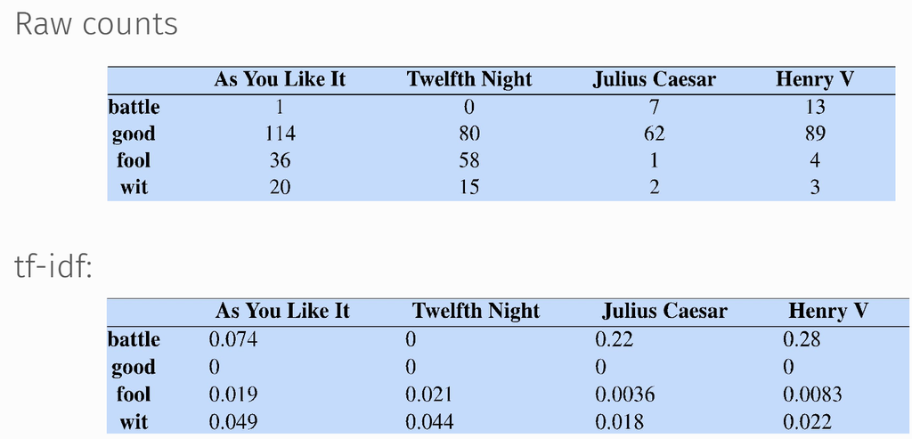